# Formation R — Séance 1 : Prise en main du logiciel R

# 6 Les vecteurs

Un **vecteur** est la structure de données fondamentale en R. C’est une séquence ordonnée d’éléments du **même type**. Presque toutes les opérations en R s’appliquent sur des vecteurs.

## 6.1 Création de vecteurs avec `c()`

La fonction `c()` (combine ou concatenate) permet de créer des vecteurs.

```r
# Vecteur numérique : notes de 6 étudiants
notes <- c(12.5, 14.0, 11.5, 16.0, 9.5, 13.0)
notes
```

```
[1] 12.5 14.0 11.5 16.0  9.5 13.0
```

```r
# Vecteur de caractères : prénoms
prenoms <- c("Adjoa", "Kofi", "Aminata", "Brice", "Fatoumata", "Yao")
prenoms
```

```
[1] "Adjoa"     "Kofi"      "Aminata"   "Brice"     "Fatoumata" "Yao"
```

```r
# Vecteur logique
ont_valide <- c(TRUE, TRUE, FALSE, TRUE, FALSE, TRUE)
ont_valide
```

```
[1]  TRUE  TRUE FALSE  TRUE FALSE  TRUE
```

```r
# Séquences numériques
seq1 <- 1:10           # Entiers de 1 à 10
seq2 <- seq(0, 1, by = 0.1)   # De 0 à 1 par pas de 0.1
seq3 <- seq(2020, 2030, by = 2)  # Années paires
seq1
```

```
 [1]  1  2  3  4  5  6  7  8  9 10
```

```r
seq2
```

```
 [1] 0.0 0.1 0.2 0.3 0.4 0.5 0.6 0.7 0.8 0.9 1.0
```

```r
seq3
```

```
[1] 2020 2022 2024 2026 2028 2030
```

## 6.2 Longueur d’un vecteur — `length()`

```r
notes <- c(12.5, 14.0, 11.5, 16.0, 9.5, 13.0)

# Nombre d'éléments dans le vecteur
length(notes)
```

```
[1] 6
```

```r
prenoms <- c("Adjoa", "Kofi", "Aminata", "Brice", "Fatoumata", "Yao")
length(prenoms)
```

```
[1] 6
```

## 6.3 Somme — `sum()`

```r
# Somme de toutes les valeurs
depenses <- c(15000, 8500, 22000, 6000, 17500)
sum(depenses)  # Total des dépenses
```

```
[1] 69000
```

```r
# Somme logique : compter les vrais
ont_valide <- c(TRUE, TRUE, FALSE, TRUE, FALSE, TRUE)
sum(ont_valide)  # Nombre d'étudiants ayant validé
```

```
[1] 4
```

## 6.4 Moyenne — `mean()`

```r
notes <- c(12.5, 14.0, 11.5, 16.0, 9.5, 13.0)
mean(notes)  # Moyenne des notes
```

```
[1] 12.75
```

```r
# Moyenne des températures journalières (°C)
temperatures <- c(32.1, 34.5, 31.8, 33.2, 35.0, 30.9, 32.7)
mean(temperatures)
```

```
[1] 32.88571
```

## 6.5 Minimum et Maximum — `min()`, `max()`

```r
notes <- c(12.5, 14.0, 11.5, 16.0, 9.5, 13.0)

# Note minimale
min(notes)
```

```
[1] 9.5
```

```r
# Note maximale
max(notes)
```

```
[1] 16
```

```r
# Les deux en même temps avec range()
range(notes)
```

```
[1]  9.5 16.0
```

## 6.6 Médiane — `median()`

```r
notes <- c(12.5, 14.0, 11.5, 16.0, 9.5, 13.0)

# Médiane des notes
median(notes)
```

```
[1] 12.75
```

```r
# Comparaison moyenne vs médiane
# Avec une valeur extrême (outlier)
revenus <- c(150000, 200000, 180000, 160000, 2500000)  # dernier = millionnaire
cat("Moyenne des revenus :", mean(revenus), "\n")
```

```
Moyenne des revenus : 638000
```

```r
cat("Médiane des revenus :", median(revenus), "\n")
```

```
Médiane des revenus : 180000
```

```r
# La médiane est plus robuste aux valeurs extrêmes
```

## 6.7 Accéder aux éléments d’un vecteur

```r
notes <- c(12.5, 14.0, 11.5, 16.0, 9.5, 13.0)

# Accéder au premier élément (indices commencent à 1 en R !)
notes[1]
```

```
[1] 12.5
```

```r
# Accéder au 4ème élément
notes[4]
```

```
[1] 16
```

```r
# Accéder à plusieurs éléments
notes[c(1, 3, 5)]
```

```
[1] 12.5 11.5  9.5
```

```r
# Accéder à une plage
notes[2:4]
```

```
[1] 14.0 11.5 16.0
```

```r
# Exclure un élément (indice négatif)
notes[-1]   # Tout sauf le premier
```

```
[1] 14.0 11.5 16.0  9.5 13.0
```

## 6.8 Exercices corrigés

**Mise en gardeExercice 4 — Manipulation de vecteurs**

On dispose des données suivantes sur 8 ménages d’un village :

- Nombre d’enfants : 3, 1, 5, 2, 4, 0, 3, 6
- Revenus mensuels (FCFA) : 85000, 120000, 65000, 200000, 95000, 180000, 75000, 110000
1. Créez un vecteur `nb_enfants` et un vecteur `revenus`
2. Combien y a-t-il de ménages ?
3. Quel est le nombre moyen d’enfants par ménage ?
4. Quel est le revenu total de l’ensemble des ménages ?
5. Quels sont les revenus minimum et maximum ?
6. Quelle est la médiane des revenus ?

**Correction :**

```r
# 1. Création des vecteurs
nb_enfants <- c(3, 1, 5, 2, 4, 0, 3, 6)
revenus <- c(85000, 120000, 65000, 200000, 95000, 180000, 75000, 110000)

# 2. Nombre de ménages
nb_menages <- length(nb_enfants)
cat("Nombre de ménages :", nb_menages, "\n")
```

```
Nombre de ménages : 8
```

```r
# 3. Nombre moyen d'enfants
moy_enfants <- mean(nb_enfants)
cat("Nombre moyen d'enfants :", moy_enfants, "\n")
```

```
Nombre moyen d'enfants : 3
```

```r
# 4. Revenu total
revenu_total <- sum(revenus)
cat("Revenu total :", format(revenu_total, big.mark = " "), "FCFA\n")
```

```
Revenu total : 930 000 FCFA
```

```r
# 5. Revenus min et max
cat("Revenu minimum :", format(min(revenus), big.mark = " "), "FCFA\n")
```

```
Revenu minimum : 65 000 FCFA
```

```r
cat("Revenu maximum :", format(max(revenus), big.mark = " "), "FCFA\n")
```

```
Revenu maximum : 200 000 FCFA
```

```r
# 6. Médiane des revenus
mediane_revenus <- median(revenus)
cat("Médiane des revenus :", format(mediane_revenus, big.mark = " "), "FCFA\n")
```

```
Médiane des revenus : 102 500 FCFA
```

# 7 Introduction aux data frames

Un **data frame** est la structure de données la plus utilisée en R pour représenter des tableaux de données, similaire à un tableau Excel. Chaque colonne représente une variable et chaque ligne représente une observation.

## 7.1 Création d’un data frame — `data.frame()`

```r
# Création d'un data frame simple
# Données sur des étudiants
etudiants <- data.frame(
  nom = c("Adjoa Mensah", "Kofi Atsu", "Aminata Diallo", "Brice Hounsa", "Fatoumata Traoré"),
  age = c(22, 24, 21, 23, 20),
  filiere = c("Statistique", "Démographie", "Statistique", "Informatique", "Économie"),
  note_maths = c(14.5, 11.0, 16.5, 13.0, 12.5),
  a_valide = c(TRUE, FALSE, TRUE, TRUE, TRUE)
)

# Afficher le data frame
etudiants
```

| nom | age | filiere | note_maths | a_valide |
| --- | --- | --- | --- | --- |
| Adjoa Mensah | 22 | Statistique | 14.5 | TRUE |
| Kofi Atsu | 24 | Démographie | 11 | FALSE |
| Aminata Diallo | 21 | Statistique | 16.5 | TRUE |
| Brice Hounsa | 23 | Informatique | 13 | TRUE |
| Fatoumata Traoré | 20 | Économie | 12.5 | TRUE |

## 7.2 Explorer un data frame

### 7.2.1 `View()` — Affichage tabulaire complet

```r
# Ouvre un onglet avec une vue tableur (uniquement dans RStudio)
View(etudiants)
```

### 7.2.2 `head()` et `tail()` — Premières et dernières lignes

```r
# Créons un data frame plus grand pour l'exemple
set.seed(42)
donnees_sante <- data.frame(
  id = 1:20,
  age = sample(18:65, 20, replace = TRUE),
  sexe = sample(c("Masculin", "Féminin"), 20, replace = TRUE),
  poids_kg = round(runif(20, 45, 95), 1),
  taille_cm = sample(155:190, 20, replace = TRUE),
  tension_sys = sample(100:160, 20, replace = TRUE)
)

# Afficher les 6 premières lignes (par défaut)
head(donnees_sante)
```

| id | age | sexe | poids_kg | taille_cm | tension_sys |
| --- | --- | --- | --- | --- | --- |
| 1 | 54 | Féminin | 92.9 | 156 | 117 |
| 2 | 18 | Masculin | 89.4 | 157 | 123 |
| 3 | 42 | Masculin | 77 | 175 | 148 |
| 4 | 27 | Masculin | 93.5 | 156 | 117 |
| 5 | 53 | Masculin | 75.9 | 164 | 104 |
| 6 | 35 | Féminin | 61.7 | 159 | 145 |

```r
# Afficher les 3 premières lignes
head(donnees_sante, 3)
```

| id | age | sexe | poids_kg | taille_cm | tension_sys |
| --- | --- | --- | --- | --- | --- |
| 1 | 54 | Féminin | 92.9 | 156 | 117 |
| 2 | 18 | Masculin | 89.4 | 157 | 123 |
| 3 | 42 | Masculin | 77 | 175 | 148 |

```r
# Afficher les 4 dernières lignes
tail(donnees_sante, 4)
```

| id | age | sexe | poids_kg | taille_cm | tension_sys |
| --- | --- | --- | --- | --- | --- |
| 17 | 20 | Masculin | 94.1 | 182 | 126 |
| 18 | 58 | Féminin | 83 | 159 | 112 |
| 19 | 42 | Féminin | 73.3 | 182 | 152 |
| 20 | 44 | Féminin | 87.5 | 156 | 153 |

### 7.2.3 `str()` — Structure du data frame

```r
# Structure détaillée : types, dimensions, premiers éléments
str(etudiants)
```

```
'data.frame':   5 obs. of  5 variables:
 $ nom       : chr  "Adjoa Mensah" "Kofi Atsu" "Aminata Diallo" "Brice Hounsa" ...
 $ age       : num  22 24 21 23 20
 $ filiere   : chr  "Statistique" "Démographie" "Statistique" "Informatique" ...
 $ note_maths: num  14.5 11 16.5 13 12.5
 $ a_valide  : logi  TRUE FALSE TRUE TRUE TRUE
```

### 7.2.4 `summary()` — Résumé statistique

```r
# Résumé statistique de chaque variable
summary(etudiants)
```

```
        nom          age          filiere     note_maths    a_valide
 Length   : 5   Min.   :20   Length   : 5   Min.   :11.0   Mode :logical
 N.unique : 5   1st Qu.:21   N.unique : 4   1st Qu.:12.5   FALSE:1
 N.blank  : 0   Median :22   N.blank  : 0   Median :13.0   TRUE :4
 Min.nchar: 9   Mean   :22   Min.nchar: 8   Mean   :13.5
 Max.nchar:16   3rd Qu.:23   Max.nchar:12   3rd Qu.:14.5
                Max.   :24                  Max.   :16.5
```

## 7.3 Accéder aux colonnes d’un data frame

```r
# Méthode 1 : avec le symbole $
etudiants$nom
```

```
[1] "Adjoa Mensah"     "Kofi Atsu"        "Aminata Diallo"   "Brice Hounsa"
[5] "Fatoumata Traoré"
```

```r
etudiants$note_maths
```

```
[1] 14.5 11.0 16.5 13.0 12.5
```

```r
# Méthode 2 : avec les crochets doubles [[ ]]
etudiants[["age"]]
```

```
[1] 22 24 21 23 20
```

```r
# Méthode 3 : par position [ligne, colonne]
etudiants[, 1]   # Toute la première colonne
```

```
[1] "Adjoa Mensah"     "Kofi Atsu"        "Aminata Diallo"   "Brice Hounsa"
[5] "Fatoumata Traoré"
```

```r
etudiants[2, ]   # Toute la deuxième ligne
```

| nom | age | filiere | note_maths | a_valide |
| --- | --- | --- | --- | --- |
| Kofi Atsu | 24 | Démographie | 11 | FALSE |

```r
etudiants[2, 3]  # Ligne 2, colonne 3
```

```
[1] "Démographie"
```

```r
# Calculs sur des colonnes
mean(etudiants$note_maths)
```

```
[1] 13.5
```

```r
max(etudiants$age)
```

```
[1] 24
```

```r
# Filtrer des lignes
# Étudiants ayant validé
etudiants_valides <- etudiants[etudiants$a_valide == TRUE, ]
etudiants_valides
```

| nom | age | filiere | note_maths | a_valide |
| --- | --- | --- | --- | --- |
| Adjoa Mensah | 22 | Statistique | 14.5 | TRUE |
| Aminata Diallo | 21 | Statistique | 16.5 | TRUE |
| Brice Hounsa | 23 | Informatique | 13 | TRUE |
| Fatoumata Traoré | 20 | Économie | 12.5 | TRUE |

## 7.4 Dimensions d’un data frame

```r
# Nombre de lignes et de colonnes
nrow(etudiants)   # Nombre de lignes (observations)
```

```
[1] 5
```

```r
ncol(etudiants)   # Nombre de colonnes (variables)
```

```
[1] 5
```

```r
dim(etudiants)    # Les deux en même temps
```

```
[1] 5 5
```

```r
# Noms des colonnes
colnames(etudiants)
```

```
[1] "nom"        "age"        "filiere"    "note_maths" "a_valide"
```

```r
names(etudiants)
```

```
[1] "nom"        "age"        "filiere"    "note_maths" "a_valide"
```

## 7.5 Exercices pratiques

**Mise en gardeExercice 5 — Data frames**

Créez un data frame `villages` contenant les informations suivantes sur 6 villages :

| Village | Département | Population | Nb_écoles | Électrifié |
| --- | --- | --- | --- | --- |
| Kpassa | Borgou | 3420 | 2 | TRUE |
| Sinendé | Alibori | 5210 | 3 | FALSE |
| Gogounou | Alibori | 4180 | 2 | TRUE |
| Ndali | Borgou | 2890 | 1 | FALSE |
| Bembèrèkè | Borgou | 6350 | 4 | TRUE |
| Kalalé | Borgou | 3780 | 2 | FALSE |

1. Affichez la structure du data frame avec `str()`
2. Affichez le résumé statistique avec `summary()`
3. Quelle est la population totale de ces 6 villages ?
4. Quel est le nom du village le plus peuplé ?
5. Combien de villages sont électrifiés ?

**Correction :**

```r
# Création du data frame
villages <- data.frame(
  village = c("Kpassa", "Sinendé", "Gogounou", "Ndali", "Bembèrèkè", "Kalalé"),
  departement = c("Borgou", "Alibori", "Alibori", "Borgou", "Borgou", "Borgou"),
  population = c(3420, 5210, 4180, 2890, 6350, 3780),
  nb_ecoles = c(2, 3, 2, 1, 4, 2),
  electrifie = c(TRUE, FALSE, TRUE, FALSE, TRUE, FALSE)
)

# 1. Structure
str(villages)
```

```
'data.frame':   6 obs. of  5 variables:
 $ village    : chr  "Kpassa" "Sinendé" "Gogounou" "Ndali" ...
 $ departement: chr  "Borgou" "Alibori" "Alibori" "Borgou" ...
 $ population : num  3420 5210 4180 2890 6350 3780
 $ nb_ecoles  : num  2 3 2 1 4 2
 $ electrifie : logi  TRUE FALSE TRUE FALSE TRUE FALSE
```

```r
# 2. Résumé statistique
summary(villages)
```

```
      village     departement   population     nb_ecoles     electrifie
 Length   :6   Length   :6    Min.   :2890   Min.   :1.000   Mode :logical
 N.unique :6   N.unique :2    1st Qu.:3510   1st Qu.:2.000   FALSE:3
 N.blank  :0   N.blank  :0    Median :3980   Median :2.000   TRUE :3
 Min.nchar:5   Min.nchar:6    Mean   :4305   Mean   :2.333
 Max.nchar:9   Max.nchar:7    3rd Qu.:4952   3rd Qu.:2.750
                              Max.   :6350   Max.   :4.000
```

```r
# 3. Population totale
pop_totale <- sum(villages$population)
cat("Population totale :", format(pop_totale, big.mark = " "), "habitants\n")
```

```
Population totale : 25 830 habitants
```

```r
# 4. Village le plus peuplé
indice_max <- which.max(villages$population)
cat("Village le plus peuplé :", villages$village[indice_max], "\n")
```

```
Village le plus peuplé : Bembèrèkè
```

```r
cat("Population :", villages$population[indice_max], "habitants\n")
```

```
Population : 6350 habitants
```

```r
# 5. Nombre de villages électrifiés
nb_electrifies <- sum(villages$electrifie)
cat("Nombre de villages électrifiés :", nb_electrifies, "sur", nrow(villages), "\n")
```

```
Nombre de villages électrifiés : 3 sur 6
```

# 8 Importation de données Excel

Dans la pratique, les données sont souvent stockées dans des fichiers Excel (`.xlsx` ou `.xls`). Le package `readxl` permet d’importer ces fichiers directement dans R.

## 8.1 Installation du package `readxl`

Un **package** est une extension qui ajoute des fonctionnalités à R. Pour utiliser un package, il faut d’abord l’installer (une seule fois), puis le charger à chaque session.

```r
# Installation du package readxl (à faire une seule fois)
install.packages("readxl")
```

**ImportantÀ retenir — Installation vs Chargement d’un package**

- **Installation** : `install.packages("nom_package")` — À faire **une seule fois**
- **Chargement** : `library(nom_package)` — À faire **à chaque nouvelle session R**

Analogie : Installer un package = acheter un livre. Charger un package = ouvrir ce livre pour le lire.

## 8.2 Chargement avec `library()`

```r
# Chargement du package (à faire à chaque session)
library(readxl)
```

## 8.3 Importation avec `read_excel()`

```r
# Syntaxe de base
donnees <- read_excel("chemin/vers/fichier.xlsx")

# Avec options avancées
donnees <- read_excel(
  path = "fichier.xlsx",      # Chemin du fichier
  sheet = "Feuil1",           # Nom ou numéro de la feuille
  skip = 0,                   # Nombre de lignes à ignorer en début
  na = c("", "N/A", "-"),    # Valeurs considérées comme manquantes
  col_names = TRUE            # Première ligne = noms des colonnes
)
```

## 8.4 Exemple complet

```r
# Simulation : créons d'abord un fichier Excel pour l'exemple
# (Dans un cas réel, le fichier existerait déjà)

# Créons des données d'exemple
donnees_ecole <- data.frame(
  ID_Eleve = 1:10,
  Prenom = c("Adjoua", "Kofi", "Mani", "Brice", "Fatouma",
             "Yao", "Aïssata", "Désiré", "Nadia", "Théo"),
  Sexe = c("F", "M", "M", "M", "F", "M", "F", "M", "F", "M"),
  Age = c(11, 12, 11, 13, 12, 11, 12, 12, 11, 13),
  Note_Francais = c(14, 11, 15, 12, 16, 10, 13, 14, 15, 11),
  Note_Maths = c(16, 14, 12, 15, 13, 18, 11, 14, 17, 12)
)

# Si readxl est installé et le fichier existe :
# donnees <- read_excel("donnees_ecole.xlsx", sheet = 1)

# Pour cet exemple, utilisons directement le data frame créé
cat("Dimensions du jeu de données :", nrow(donnees_ecole), "lignes x",
    ncol(donnees_ecole), "colonnes\n")
```

```
Dimensions du jeu de données : 10 lignes x 6 colonnes
```

```r
head(donnees_ecole)
```

| ID_Eleve | Prenom | Sexe | Age | Note_Francais | Note_Maths |
| --- | --- | --- | --- | --- | --- |
| 1 | Adjoua | F | 11 | 14 | 16 |
| 2 | Kofi | M | 12 | 11 | 14 |
| 3 | Mani | M | 11 | 15 | 12 |
| 4 | Brice | M | 13 | 12 | 15 |
| 5 | Fatouma | F | 12 | 16 | 13 |
| 6 | Yao | M | 11 | 10 | 18 |

**AstuceConseil — Définir le répertoire de travail**

Avant d’importer des fichiers, définissez votre répertoire de travail avec `setwd()` ou utilisez des chemins absolus :

```r
# Définir le répertoire de travail
setwd("C:/Users/MonNom/Documents/Formation_R")

# Puis importer directement
donnees <- read_excel("mes_donnees.xlsx")
```

Dans RStudio, vous pouvez aussi utiliser : `Session > Set Working Directory > Choose Directory`

**NoteAutres formats d’importation**

R peut importer de nombreux formats de données :

| Format | Package | Fonction |
| --- | --- | --- |
| Excel (.xlsx) | `readxl` | `read_excel()` |
| CSV | Base R | `read.csv()` |
| Stata (.dta) | `haven` | `read_dta()` |
| SPSS (.sav) | `haven` | `read_sav()` |
| JSON | `jsonlite` | `fromJSON()` |

# 9 Statistiques descriptives simples

Les statistiques descriptives permettent de résumer et de caractériser un jeu de données. R fournit toutes les fonctions nécessaires nativement.

## 9.1 Jeu de données d’exemple

```r
# Jeu de données : résultats d'une enquête dans un lycée
set.seed(123)
n <- 50  # 50 élèves

enquete_lycee <- data.frame(
  id = 1:n,
  sexe = sample(c("Garçon", "Fille"), n, replace = TRUE, prob = c(0.55, 0.45)),
  age = sample(14:20, n, replace = TRUE),
  classe = sample(c("2nde", "1ère", "Terminale"), n, replace = TRUE),
  note_francais = round(runif(n, 6, 19), 1),
  note_maths = round(runif(n, 4, 20), 1),
  heures_etude = sample(1:6, n, replace = TRUE)
)

# Aperçu du jeu de données
head(enquete_lycee)
```

| id | sexe | age | classe | note_francais | note_maths | heures_etude |
| --- | --- | --- | --- | --- | --- | --- |
| 1 | Garçon | 17 | 2nde | 11.4 | 17.1 | 1 |
| 2 | Fille | 18 | Terminale | 9.5 | 18.7 | 1 |
| 3 | Garçon | 20 | Terminale | 14.2 | 8.5 | 5 |
| 4 | Fille | 18 | 1ère | 8.4 | 19.4 | 5 |
| 5 | Fille | 16 | Terminale | 17.2 | 15.7 | 3 |
| 6 | Garçon | 19 | 2nde | 15.7 | 15 | 2 |

```r
dim(enquete_lycee)
```

```
[1] 50  7
```

## 9.2 Moyenne — `mean()`

```r
# Moyenne de la note de français
moy_francais <- mean(enquete_lycee$note_francais)
cat("Moyenne en français :", round(moy_francais, 2), "\n")
```

```
Moyenne en français : 12.69
```

```r
# Moyenne de la note de maths
moy_maths <- mean(enquete_lycee$note_maths)
cat("Moyenne en maths :", round(moy_maths, 2), "\n")
```

```
Moyenne en maths : 12.86
```

## 9.3 Médiane — `median()`

```r
# Médiane des notes
med_francais <- median(enquete_lycee$note_francais)
cat("Médiane en français :", med_francais, "\n")
```

```
Médiane en français : 12.5
```

```r
# Comparaison moyenne/médiane
cat("\nComparaison Français :\n")
```

```
Comparaison Français :
```

```r
cat("  Moyenne :", round(moy_francais, 2), "\n")
```

```
  Moyenne : 12.69
```

```r
cat("  Médiane :", med_francais, "\n")
```

```
  Médiane : 12.5
```

## 9.4 Écart-type — `sd()`

L’écart-type mesure la dispersion des données autour de la moyenne. Plus il est grand, plus les données sont dispersées.

```r
# Écart-type des notes
et_francais <- sd(enquete_lycee$note_francais)
et_maths <- sd(enquete_lycee$note_maths)

cat("Écart-type Français :", round(et_francais, 2), "\n")
```

```
Écart-type Français : 3.26
```

```r
cat("Écart-type Maths    :", round(et_maths, 2), "\n")
```

```
Écart-type Maths    : 4.28
```

## 9.5 Fréquences — `table()`

La fonction `table()` calcule les fréquences absolues (effectifs) d’une variable qualitative.

```r
# Fréquences par sexe
freq_sexe <- table(enquete_lycee$sexe)
freq_sexe
```

```
 Fille Garçon
    23     27
```

```r
# Fréquences par classe
freq_classe <- table(enquete_lycee$classe)
freq_classe
```

```
     1ère      2nde Terminale
       21         8        21
```

```r
# Tableau croisé (sexe × classe)
tab_croise <- table(enquete_lycee$sexe, enquete_lycee$classe)
tab_croise
```

```
         1ère 2nde Terminale
  Fille    13    1         9
  Garçon    8    7        12
```

## 9.6 Pourcentages — `prop.table()`

La fonction `prop.table()` calcule les proportions (fréquences relatives) à partir d’un tableau de fréquences.

```r
# Proportions par sexe
prop_sexe <- prop.table(freq_sexe)
prop_sexe
```

```
 Fille Garçon
  0.46   0.54
```

```r
# Pourcentages (multiplier par 100)
pct_sexe <- round(prop.table(freq_sexe) * 100, 1)
cat("\nRépartition par sexe :\n")
```

```
Répartition par sexe :
```

```r
print(pct_sexe)
```

```
 Fille Garçon
    46     54
```

```r
# Proportions du tableau croisé
# margin = 1 : proportions en ligne ; margin = 2 : proportions en colonne
prop_tab <- round(prop.table(tab_croise, margin = 1) * 100, 1)
cat("\nRépartition par classe selon le sexe (en %) :\n")
```

```
Répartition par classe selon le sexe (en %) :
```

```r
print(prop_tab)
```

```
         1ère 2nde Terminale
  Fille  56.5  4.3      39.1
  Garçon 29.6 25.9      44.4
```

## 9.7 Résumé complet avec `summary()`

```r
# Résumé de toutes les variables numériques
summary(enquete_lycee[, c("age", "note_francais", "note_maths", "heures_etude")])
```

```
      age        note_francais     note_maths     heures_etude
 Min.   :14.00   Min.   : 6.60   Min.   : 4.80   Min.   :1.00
 1st Qu.:15.00   1st Qu.: 9.80   1st Qu.: 9.45   1st Qu.:1.25
 Median :18.00   Median :12.50   Median :12.85   Median :3.00
 Mean   :17.22   Mean   :12.69   Mean   :12.86   Mean   :3.20
 3rd Qu.:19.00   3rd Qu.:14.78   3rd Qu.:16.38   3rd Qu.:5.00
 Max.   :20.00   Max.   :18.80   Max.   :19.50   Max.   :6.00
```

`summary()` affiche automatiquement : - **Min** : valeur minimale - **1st Qu.** : premier quartile (25% des données en dessous) - **Median** : médiane (50%) - **Mean** : moyenne arithmétique - **3rd Qu.** : troisième quartile (75%) - **Max** : valeur maximale

# 10 Premiers graphiques

R est réputé pour la qualité de ses graphiques. Dans cette séance, nous découvrons les deux fonctions graphiques de base les plus utilisées.

## 10.1 L’histogramme — `hist()`

L’histogramme représente la distribution d’une variable quantitative continue en classes.

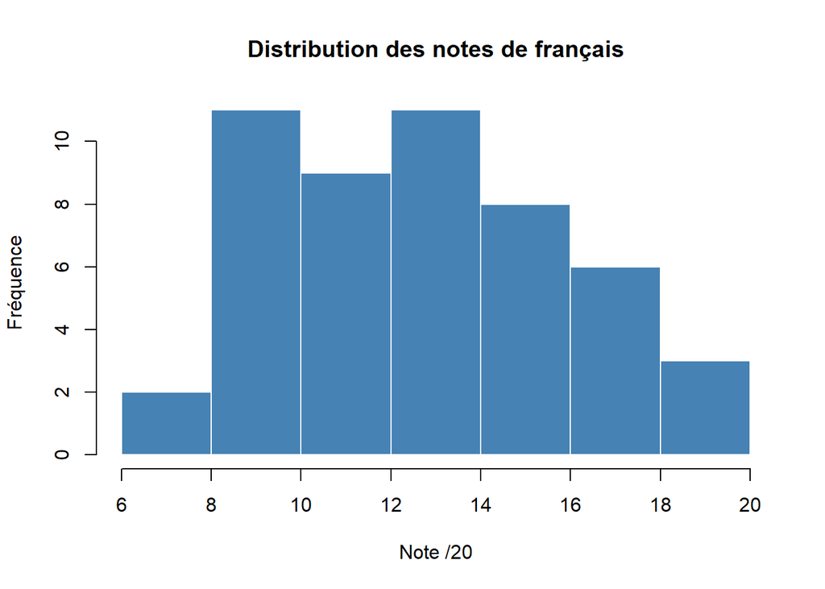

```r
# Histogramme simple des notes de français
hist(enquete_lycee$note_francais,
     main = "Distribution des notes de français",  # Titre
     xlab = "Note /20",                            # Label axe X
     ylab = "Fréquence",                           # Label axe Y
     col = "steelblue",                            # Couleur
     border = "white")                             # Couleur bordure
```

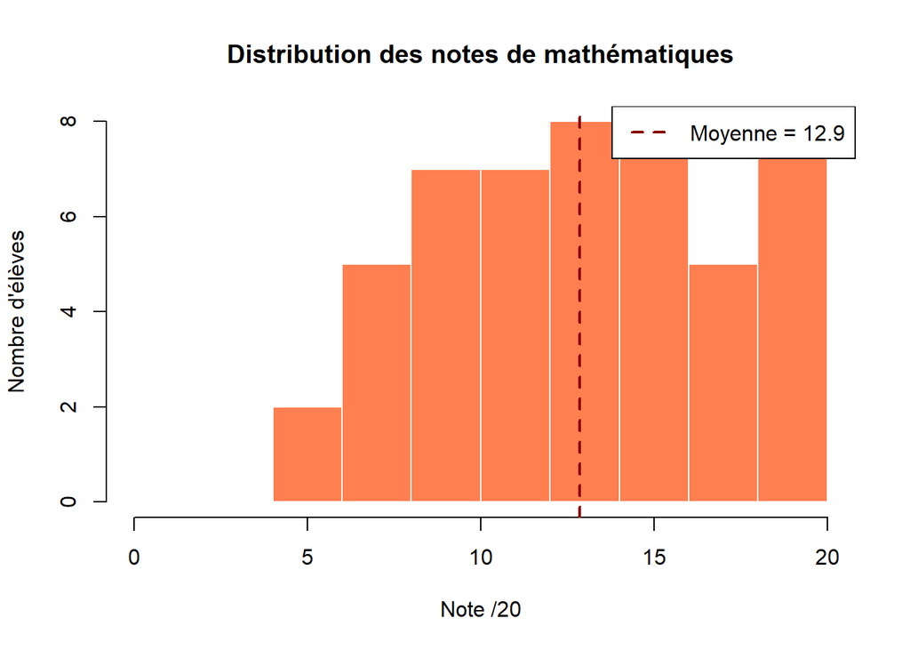

```r
# Histogramme avec plus d'options
hist(enquete_lycee$note_maths,
     main = "Distribution des notes de mathématiques",
     xlab = "Note /20",
     ylab = "Nombre d'élèves",
     col = "coral",
     border = "white",
     breaks = 10,           # Nombre de classes
     xlim = c(0, 20))       # Limites de l'axe X

# Ajouter une ligne de moyenne
abline(v = mean(enquete_lycee$note_maths),
       col = "darkred", lwd = 2, lty = 2)
legend("topright", legend = paste("Moyenne =", round(mean(enquete_lycee$note_maths), 1)),
       col = "darkred", lty = 2, lwd = 2)
```

## 10.2 Le diagramme en barres — `barplot()`

Le diagramme en barres représente les fréquences ou les valeurs d’une variable qualitative.

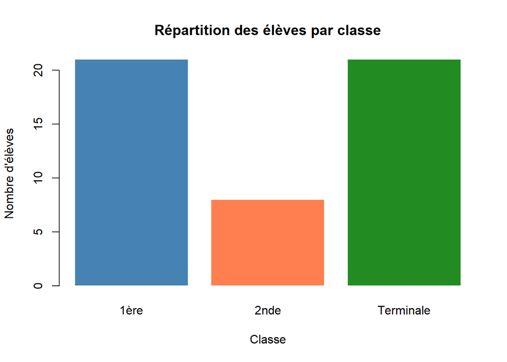

```r
# Diagramme en barres de la répartition par classe
barplot(table(enquete_lycee$classe),
        main = "Répartition des élèves par classe",
        xlab = "Classe",
        ylab = "Nombre d'élèves",
        col = c("steelblue", "coral", "forestgreen"),
        border = "white")
```

[figure not shown]

```r
# Diagramme en barres groupées (sexe par classe)
barplot(table(enquete_lycee$sexe, enquete_lycee$classe),
        beside = TRUE,    # Barres côte à côte
        main = "Répartition par classe et par sexe",
        xlab = "Classe",
        ylab = "Nombre d'élèves",
        col = c("steelblue", "coral"),
        border = "white",
        legend.text = c("Garçon", "Fille"),
        args.legend = list(x = "topright"))
```

**AstuceChoisir le bon graphique**

| Type de variable | Graphique recommandé |
| --- | --- |
| Variable quantitative continue | Histogramme (`hist`) |
| Variable qualitative | Diagramme en barres (`barplot`) |
| Deux variables quantitatives | Nuage de points (`plot`) |
| Évolution dans le temps | Graphique en courbes (`plot` avec `type="l"`) |

# 11 Exercices de synthèse

**Mise en gardeExercice 6**

Calculez dans R les expressions suivantes : 1. $\frac{(45 + 38 + 72 + 51)}{4}$ 2. $\sqrt{(3^2 + 4^2)}$ 3. $\frac{1}{1 + e^{-2}}$ (fonction logistique en $x = 2$)

**Mise en gardeExercice 7**

Créez les variables suivantes et affichez-les : - `pays` : “Bénin” - `superficie` : 114763 (km²) - `population_2023` : 13352864 - `pib_milliards_usd` : 17.8 - `membre_ua` : TRUE

Ensuite, calculez et affichez la densité de population.

**Mise en gardeExercice 8**

On a mesuré la hauteur (en cm) de 10 plants de maïs : `128, 145, 132, 118, 156, 141, 129, 147, 135, 122`

1. Créez un vecteur `hauteurs`
2. Calculez la hauteur minimale, maximale, moyenne et médiane
3. Combien de plants mesurent plus de 135 cm ? (Indice : `sum(hauteurs > 135)`)
4. Calculez l’écart-type

**Mise en gardeExercice 9**

Créez un data frame `personnel` avec 5 employés :

| Nom | Département | Ancienneté (ans) | Salaire (FCFA) | Cadre |
| --- | --- | --- | --- | --- |
| AHOYO Bernard | Statistiques | 8 | 450000 | TRUE |
| DOSSOU Clémence | Informatique | 3 | 320000 | FALSE |
| SOSSA Patrick | RH | 12 | 580000 | TRUE |
| KPADA Nathalie | Comptabilité | 5 | 380000 | FALSE |
| AGBO Rémi | Statistiques | 15 | 650000 | TRUE |

1. Affichez la structure avec `str()`
2. Quel est le salaire moyen ?
3. Quel est le salaire du cadre le plus ancien ?
4. Combien d’employés sont cadres ?

**Mise en gardeExercice 10**

Utilisez le data frame `donnees_sante` créé en section 7.2.2 pour :

1. Calculer la taille moyenne des patients
2. Calculer le poids minimum et maximum
3. Créer un tableau de fréquences du sexe
4. Calculer les pourcentages par sexe
5. Tracer un histogramme de la tension systolique

**Mise en gardeExercice 11**

À partir du vecteur suivant de températures journalières (°C) sur 30 jours :

```r
temperatures <- c(28.5, 31.2, 33.8, 29.4, 35.1, 32.7, 30.1,
                  34.5, 31.8, 28.9, 36.2, 33.1, 29.7, 31.5, 34.8,
                  30.3, 32.9, 35.6, 29.1, 33.4, 31.7, 28.3, 34.2,
                  30.8, 32.1, 35.9, 29.6, 33.7, 31.2, 30.5)
```

1. Calculez la température minimale, maximale, moyenne et médiane
2. Combien de jours la température a-t-elle dépassé 33°C ?
3. Quel est l’écart-type des températures ?
4. Tracez un histogramme des températures

**Mise en gardeExercice 12**

Créez un vecteur `notes_classe` contenant 20 notes d’élèves (inventez des valeurs entre 5 et 20), puis :

1. Calculez toutes les statistiques descriptives principales
2. Créez un vecteur `mention` qui indique la mention selon la note :
   - “Passable” si note < 12
   - “Assez bien” si 12 ≤ note < 14
   - “Bien” si 14 ≤ note < 16
   - “Très bien” si note ≥ 16
3. Créez un tableau de fréquences des mentions

**Mise en gardeExercice 13**

À partir du data frame `enquete_lycee` créé en section 9, répondez aux questions :

1. Quelle est la note moyenne en français des filles ? (Indice : filtrez d’abord les filles)
2. Quelle est la note moyenne en maths des garçons ?
3. Combien d’élèves étudient plus de 3 heures par jour ?
4. Quel pourcentage d’élèves sont en Terminale ?

**Mise en gardeExercice 14**

Créez un diagramme en barres représentant le nombre de communes par département pour les 5 premiers départements du Bénin :

| Département | Nb Communes |
| --- | --- |
| Alibori | 6 |
| Atacora | 9 |
| Atlantique | 8 |
| Borgou | 12 |
| Collines | 6 |

Ajoutez un titre, des labels d’axes et des couleurs différentes pour chaque barre.

**Mise en gardeExercice 15**

Vous disposez des données suivantes sur la vaccination dans 6 communes :

| Commune | Cible | Vaccinés |
| --- | --- | --- |
| A | 1200 | 1056 |
| B | 850 | 740 |
| C | 2100 | 1890 |
| D | 650 | 598 |
| E | 1800 | 1512 |
| F | 950 | 817 |

1. Créez un data frame `vaccination`
2. Calculez le taux de couverture vaccinale pour chaque commune (vaccinés/cible × 100)
3. Ajoutez cette nouvelle colonne au data frame
4. Quelle commune a le meilleur taux de couverture ?
5. Tracez un histogramme des taux de couverture

# 12 Corrigés détaillés

## 12.1 Corrigé — Exercice 6

```r
# 1. Calcul de la moyenne de 4 valeurs
(45 + 38 + 72 + 51) / 4
```

```
[1] 51.5
```

```r
# 2. Hypoténuse (théorème de Pythagore)
sqrt(3^2 + 4^2)
```

```
[1] 5
```

```r
# 3. Fonction logistique en x = 2
1 / (1 + exp(-2))
```

```
[1] 0.8807971
```

## 12.2 Corrigé — Exercice 7

```r
# Création des variables
pays <- "Bénin"
superficie <- 114763
population_2023 <- 13352864
pib_milliards_usd <- 17.8
membre_ua <- TRUE

# Affichage
cat("Pays :", pays, "\n")
```

```
Pays : Bénin
```

```r
cat("Superficie :", format(superficie, big.mark = " "), "km²\n")
```

```
Superficie : 114 763 km²
```

```r
cat("Population 2023 :", format(population_2023, big.mark = " "), "\n")
```

```
Population 2023 : 13 352 864
```

```r
cat("PIB :", pib_milliards_usd, "milliards USD\n")
```

```
PIB : 17.8 milliards USD
```

```r
cat("Membre UA :", membre_ua, "\n")
```

```
Membre UA : TRUE
```

```r
# Densité de population
densite <- population_2023 / superficie
cat("\nDensité de population :", round(densite, 1), "habitants/km²\n")
```

```
Densité de population : 116.4 habitants/km²
```

## 12.3 Corrigé — Exercice 8

```r
# 1. Création du vecteur
hauteurs <- c(128, 145, 132, 118, 156, 141, 129, 147, 135, 122)

# 2. Statistiques
cat("Hauteur minimale :", min(hauteurs), "cm\n")
```

```
Hauteur minimale : 118 cm
```

```r
cat("Hauteur maximale :", max(hauteurs), "cm\n")
```

```
Hauteur maximale : 156 cm
```

```r
cat("Hauteur moyenne  :", mean(hauteurs), "cm\n")
```

```
Hauteur moyenne  : 135.3 cm
```

```r
cat("Hauteur médiane  :", median(hauteurs), "cm\n")
```

```
Hauteur médiane  : 133.5 cm
```

```r
# 3. Plants de plus de 135 cm
nb_grands <- sum(hauteurs > 135)
cat("Plants > 135 cm  :", nb_grands, "\n")
```

```
Plants > 135 cm  : 4
```

```r
# 4. Écart-type
cat("Écart-type       :", round(sd(hauteurs), 2), "cm\n")
```

```
Écart-type       : 11.89 cm
```

## 12.4 Corrigé — Exercice 9

```r
# Création du data frame
personnel <- data.frame(
  nom = c("AHOYO Bernard", "DOSSOU Clémence", "SOSSA Patrick", "KPADA Nathalie", "AGBO Rémi"),
  departement = c("Statistiques", "Informatique", "RH", "Comptabilité", "Statistiques"),
  anciennete = c(8, 3, 12, 5, 15),
  salaire = c(450000, 320000, 580000, 380000, 650000),
  cadre = c(TRUE, FALSE, TRUE, FALSE, TRUE)
)

# 1. Structure
str(personnel)
```

```
'data.frame':   5 obs. of  5 variables:
 $ nom        : chr  "AHOYO Bernard" "DOSSOU Clémence" "SOSSA Patrick" "KPADA Nathalie" ...
 $ departement: chr  "Statistiques" "Informatique" "RH" "Comptabilité" ...
 $ anciennete : num  8 3 12 5 15
 $ salaire    : num  450000 320000 580000 380000 650000
 $ cadre      : logi  TRUE FALSE TRUE FALSE TRUE
```

```r
# 2. Salaire moyen
cat("Salaire moyen :", format(mean(personnel$salaire), big.mark = " "), "FCFA\n")
```

```
Salaire moyen : 476 000 FCFA
```

```r
# 3. Salaire du cadre le plus ancien
cadres <- personnel[personnel$cadre == TRUE, ]
cadre_plus_ancien <- cadres[which.max(cadres$anciennete), ]
cat("Cadre le plus ancien :", cadre_plus_ancien$nom, "\n")
```

```
Cadre le plus ancien : AGBO Rémi
```

```r
cat("Salaire             :", format(cadre_plus_ancien$salaire, big.mark = " "), "FCFA\n")
```

```
Salaire             : 650 000 FCFA
```

```r
# 4. Nombre de cadres
cat("Nombre de cadres :", sum(personnel$cadre), "\n")
```

```
Nombre de cadres : 3
```

## 12.5 Corrigé — Exercice 10

```r
# Recréer le data frame donnees_sante
set.seed(42)
donnees_sante <- data.frame(
  id = 1:20,
  age = sample(18:65, 20, replace = TRUE),
  sexe = sample(c("Masculin", "Féminin"), 20, replace = TRUE),
  poids_kg = round(runif(20, 45, 95), 1),
  taille_cm = sample(155:190, 20, replace = TRUE),
  tension_sys = sample(100:160, 20, replace = TRUE)
)

# 1. Taille moyenne
cat("Taille moyenne :", mean(donnees_sante$taille_cm), "cm\n")
```

```
Taille moyenne : 170.7 cm
```

```r
# 2. Poids min et max
cat("Poids minimum  :", min(donnees_sante$poids_kg), "kg\n")
```

```
Poids minimum  : 46.9 kg
```

```r
cat("Poids maximum  :", max(donnees_sante$poids_kg), "kg\n")
```

```
Poids maximum  : 94.1 kg
```

```r
# 3. Tableau de fréquences du sexe
freq_sexe <- table(donnees_sante$sexe)
print(freq_sexe)
```

```
 Féminin Masculin
      12        8
```

```r
# 4. Pourcentages par sexe
pct_sexe <- round(prop.table(freq_sexe) * 100, 1)
print(pct_sexe)
```

```
 Féminin Masculin
      60       40
```

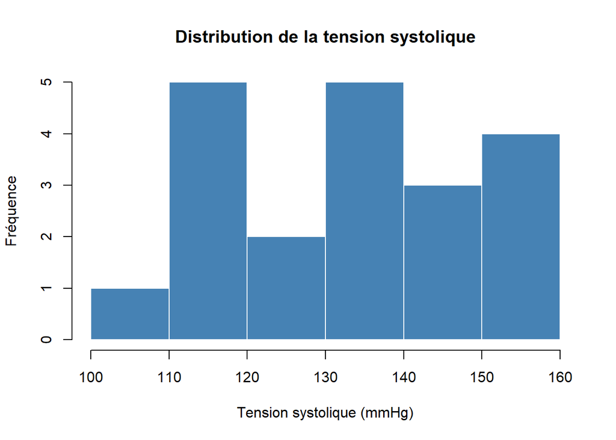

```r
# 5. Histogramme de la tension systolique
hist(donnees_sante$tension_sys,
     main = "Distribution de la tension systolique",
     xlab = "Tension systolique (mmHg)",
     ylab = "Fréquence",
     col = "steelblue",
     border = "white")
```

## 12.6 Corrigé — Exercice 11

```r
temperatures <- c(28.5, 31.2, 33.8, 29.4, 35.1, 32.7, 30.1,
                  34.5, 31.8, 28.9, 36.2, 33.1, 29.7, 31.5, 34.8,
                  30.3, 32.9, 35.6, 29.1, 33.4, 31.7, 28.3, 34.2,
                  30.8, 32.1, 35.9, 29.6, 33.7, 31.2, 30.5)

# 1. Statistiques principales
cat("Température minimale :", min(temperatures), "°C\n")
```

```
Température minimale : 28.3 °C
```

```r
cat("Température maximale :", max(temperatures), "°C\n")
```

```
Température maximale : 36.2 °C
```

```r
cat("Température moyenne  :", round(mean(temperatures), 2), "°C\n")
```

```
Température moyenne  : 32.02 °C
```

```r
cat("Température médiane  :", median(temperatures), "°C\n")
```

```
Température médiane  : 31.75 °C
```

```r
# 2. Jours au-dessus de 33°C
nb_jours_chauds <- sum(temperatures > 33)
cat("Jours > 33°C :", nb_jours_chauds, "jours sur", length(temperatures), "\n")
```

```
Jours > 33°C : 11 jours sur 30
```

```r
# 3. Écart-type
cat("Écart-type :", round(sd(temperatures), 2), "°C\n")
```

```
Écart-type : 2.34 °C
```

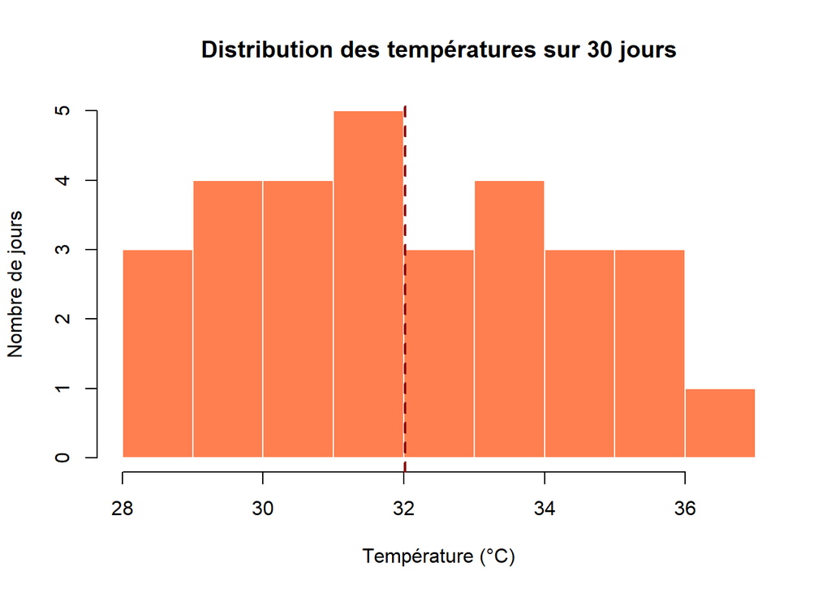

```r
# 4. Histogramme
hist(temperatures,
     main = "Distribution des températures sur 30 jours",
     xlab = "Température (°C)",
     ylab = "Nombre de jours",
     col = "coral",
     border = "white")
abline(v = mean(temperatures), col = "darkred", lwd = 2, lty = 2)
```

## 12.7 Corrigé — Exercice 12

```r
# Création d'un vecteur de 20 notes
set.seed(7)
notes_classe <- c(8, 14, 17, 11, 15, 9, 16, 12, 7, 18,
                  13, 10, 15, 6, 14, 11, 19, 12, 16, 8)

# 1. Statistiques descriptives
cat("--- Statistiques descriptives ---\n")
```

```
--- Statistiques descriptives ---
```

```r
cat("Minimum    :", min(notes_classe), "\n")
```

```
Minimum    : 6
```

```r
cat("Maximum    :", max(notes_classe), "\n")
```

```
Maximum    : 19
```

```r
cat("Moyenne    :", mean(notes_classe), "\n")
```

```
Moyenne    : 12.55
```

```r
cat("Médiane    :", median(notes_classe), "\n")
```

```
Médiane    : 12.5
```

```r
cat("Écart-type :", round(sd(notes_classe), 2), "\n")
```

```
Écart-type : 3.78
```

```r
# 2. Attribution des mentions
mention <- ifelse(notes_classe < 12, "Passable",
           ifelse(notes_classe < 14, "Assez bien",
           ifelse(notes_classe < 16, "Bien", "Très bien")))
mention
```

```
 [1] "Passable"   "Bien"       "Très bien"  "Passable"   "Bien"
 [6] "Passable"   "Très bien"  "Assez bien" "Passable"   "Très bien"
[11] "Assez bien" "Passable"   "Bien"       "Passable"   "Bien"
[16] "Passable"   "Très bien"  "Assez bien" "Très bien"  "Passable"
```

```r
# 3. Tableau de fréquences
table(mention)
```

```
mention
Assez bien       Bien   Passable  Très bien
         3          4          8          5
```

```r
round(prop.table(table(mention)) * 100, 1)
```

```
mention
Assez bien       Bien   Passable  Très bien
        15         20         40         25
```

## 12.8 Corrigé — Exercice 13

```r
# Recréer le jeu de données
set.seed(123)
n <- 50
enquete_lycee <- data.frame(
  id = 1:n,
  sexe = sample(c("Garçon", "Fille"), n, replace = TRUE, prob = c(0.55, 0.45)),
  age = sample(14:20, n, replace = TRUE),
  classe = sample(c("2nde", "1ère", "Terminale"), n, replace = TRUE),
  note_francais = round(runif(n, 6, 19), 1),
  note_maths = round(runif(n, 4, 20), 1),
  heures_etude = sample(1:6, n, replace = TRUE)
)

# 1. Note moyenne en français des filles
filles <- enquete_lycee[enquete_lycee$sexe == "Fille", ]
cat("Moyenne français (Filles)  :", round(mean(filles$note_francais), 2), "\n")
```

```
Moyenne français (Filles)  : 13
```

```r
# 2. Note moyenne en maths des garçons
garcons <- enquete_lycee[enquete_lycee$sexe == "Garçon", ]
cat("Moyenne maths (Garçons)    :", round(mean(garcons$note_maths), 2), "\n")
```

```
Moyenne maths (Garçons)    : 12.79
```

```r
# 3. Élèves étudiant plus de 3h par jour
nb_studieux <- sum(enquete_lycee$heures_etude > 3)
cat("Élèves étudiant > 3h/jour :", nb_studieux, "\n")
```

```
Élèves étudiant > 3h/jour : 22
```

```r
# 4. Pourcentage en Terminale
pct_terminale <- mean(enquete_lycee$classe == "Terminale") * 100
cat("% en Terminale            :", round(pct_terminale, 1), "%\n")
```

```
% en Terminale            : 42 %
```

## 12.9 Corrigé — Exercice 14

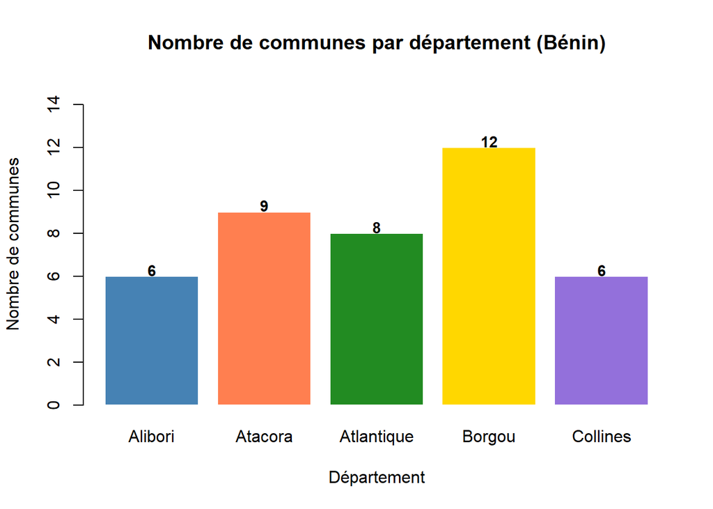

```r
# Données des communes par département
departements <- c("Alibori", "Atacora", "Atlantique", "Borgou", "Collines")
nb_communes <- c(6, 9, 8, 12, 6)
couleurs <- c("steelblue", "coral", "forestgreen", "gold", "mediumpurple")

# Diagramme en barres
barplot(nb_communes,
        names.arg = departements,
        main = "Nombre de communes par département (Bénin)",
        xlab = "Département",
        ylab = "Nombre de communes",
        col = couleurs,
        border = "white",
        ylim = c(0, 15))

# Ajouter les valeurs sur les barres
text(x = barplot(nb_communes, plot = FALSE),
     y = nb_communes + 0.3,
     labels = nb_communes,
     cex = 0.9, font = 2)
```

## 12.10 Corrigé — Exercice 15

```r
# 1. Création du data frame
vaccination <- data.frame(
  commune = c("A", "B", "C", "D", "E", "F"),
  cible = c(1200, 850, 2100, 650, 1800, 950),
  vaccines = c(1056, 740, 1890, 598, 1512, 817)
)

# 2. Calcul du taux de couverture
vaccination$taux_couverture <- round((vaccination$vaccines / vaccination$cible) * 100, 1)

# 3. Afficher le data frame avec la nouvelle colonne
print(vaccination)
```

```
  commune cible vaccines taux_couverture
1       A  1200     1056            88.0
2       B   850      740            87.1
3       C  2100     1890            90.0
4       D   650      598            92.0
5       E  1800     1512            84.0
6       F   950      817            86.0
```

```r
# 4. Commune avec le meilleur taux
meilleure_commune <- vaccination[which.max(vaccination$taux_couverture), ]
cat("\nMeilleure couverture :", meilleure_commune$commune,
    "avec", meilleure_commune$taux_couverture, "%\n")
```

```
Meilleure couverture : D avec 92 %
```

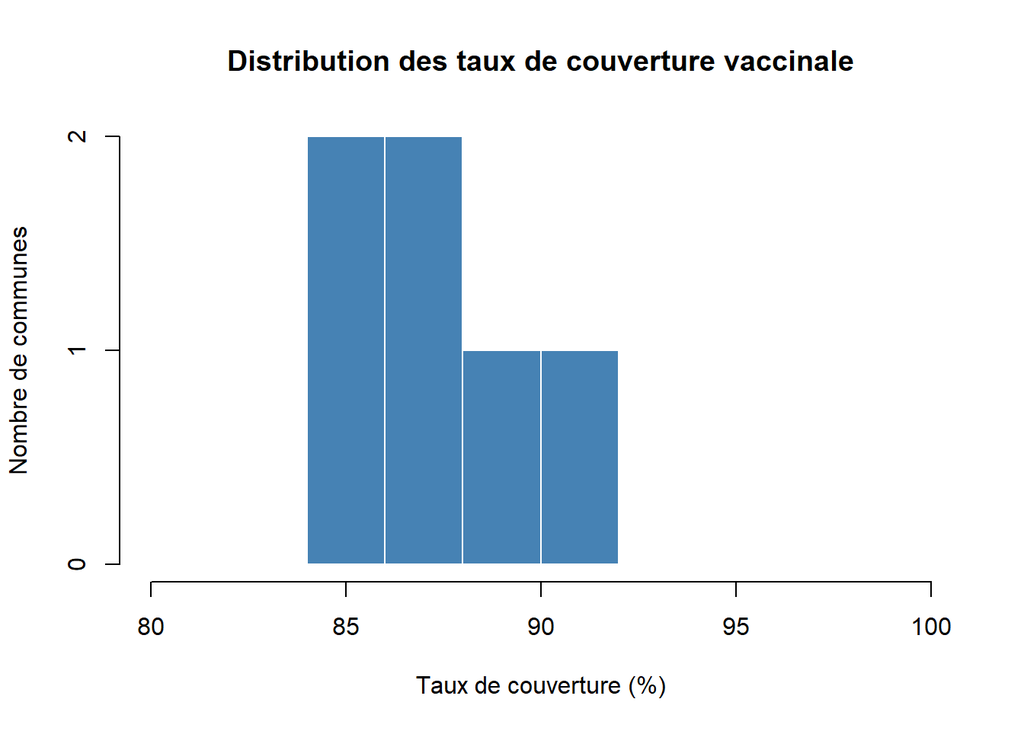

```r
# 5. Histogramme des taux
hist(vaccination$taux_couverture,
     main = "Distribution des taux de couverture vaccinale",
     xlab = "Taux de couverture (%)",
     ylab = "Nombre de communes",
     col = "steelblue",
     border = "white",
     breaks = 5,
     xlim = c(80, 100))
```

# Conclusion

## 12.11 Résumé des notions apprises

Félicitations ! À l’issue de cette première séance, vous avez acquis les bases essentielles pour travailler avec R.

**NoteCe que vous avez appris aujourd’hui**

**Environnement de travail**

- Installer R et RStudio
- Naviguer dans l’interface à 4 panneaux de RStudio
- Créer, éditer et sauvegarder un script R

**Programmation de base**

- Écrire des commandes et des commentaires dans R
- Réaliser des calculs arithmétiques (+, -, *, /, ^, sqrt)
- Créer et manipuler des variables avec l’opérateur `<-`
- Utiliser `ls()` et `rm()` pour gérer l’environnement

**Types de données**

- Distinguer les types : numérique, caractère, logique
- Utiliser `class()` et `typeof()` pour identifier les types
- Convertir entre types (`as.numeric()`, `as.character()`, etc.)

**Structures de données**

- Créer et manipuler des vecteurs avec `c()`
- Créer et explorer des data frames avec `data.frame()`
- Utiliser `head()`, `tail()`, `str()`, `summary()`

**Analyse de données**

- Importer des données Excel avec `readxl`
- Calculer des statistiques descriptives (mean, median, sd, table, prop.table)
- Produire des graphiques de base (hist, barplot)

# Travail personnel

Avant la prochaine séance, réalisez les exercices suivants à la maison pour consolider vos acquis.

**Mise en gardeDevoir à rendre — Exercice A : Script annoté**

Créez un script R nommé `devoir_seance1.R` contenant :

1. Un en-tête complet (nom, date, objectif)
2. La création d’un data frame `eleves_ecole` avec au moins 8 élèves et 5 variables de votre choix (nom, classe, sexe, note1, note2)
3. Le calcul de la moyenne de chaque note
4. L’identification de l’élève avec la meilleure moyenne
5. Un tableau de fréquences et de pourcentages par classe
6. Un histogramme de la distribution des notes
7. Des commentaires expliquant chaque étape

**Mise en gardeDevoir à rendre — Exercice B : Exploration**

Collectez (ou inventez) des données sur votre environnement proche (votre classe, votre quartier, votre famille) et créez un mini-jeu de données d’au moins 10 lignes.

Réalisez une analyse descriptive complète et produisez au moins 2 graphiques commentés.

**AstuceRessources pour aller plus loin**

**Documentation officielle**

- Site officiel R : https://www.r-project.org
- Aide intégrée RStudio : tapez `?nom_fonction` dans la console (ex: `?mean`)

**Tutoriels en ligne gratuits**

- [R for Data Science (en français)](https://r4ds.hadley.nz) — Bible de l’analyse de données avec R
- [Introduction à R et au tidyverse](https://juba.github.io/tidyverse/) — Excellent tutoriel en français
- Swirl : package interactif d’apprentissage de R (tapez `install.packages("swirl")`)

**Communauté**

- Stack Overflow : stackoverflow.com/questions/tagged/r
- R-bloggers : r-bloggers.com

**NoteAperçu de la Séance 2**

La prochaine séance couvrira :

- Le package **tidyverse** : manipulation avancée de données avec `dplyr` et `tidyr`
- Les graphiques avec **ggplot2** : visualisations professionnelles et personnalisées
- La gestion des valeurs manquantes (`NA`)
- La création de fonctions personnalisées
- Introduction aux boucles et à la programmation itérative